# AN588_Boots_imcarlyy

Carla Rojas

2025-04-14

```r
install.packages("ggplot2", repos = "https://cloud.r-project.org/")
```

# Bootstrapping Standard Errors and CIs for Linear Models

When we initially discussed the central limit theorem and confidence intervals, we showed how we could use bootstrapping to estimate standard errors and confidence intervals around certain parameter values, like the mean. Using bootstrapping, we could also do the same for estimating standard errors and CIs around regression parameters, such as β coefficients.

## [1] Using the “KamilarAndCooperData.csv” dataset, run a linear regression looking at log(HomeRange_km2) in relation to log(Body_mass_female_mean) and report your β coeffiecients (slope and intercept).

```r
library(curl)
f <- curl("https://raw.githubusercontent.com/fuzzyatelin/fuzzyatelin.github.io/refs/heads/master/AN588_Spring25/KamilarAndCooperData.csv")
d <- read.csv(f, header = TRUE, sep = ",", stringsAsFactors = TRUE)
head(d)
```

```
##               Scientific_Name          Family          Genus      Species
## 1 Allenopithecus_nigroviridis Cercopithecidae Allenopithecus nigroviridis
## 2         Allocebus_trichotis Cercopithecidae      Allocebus    trichotis
## 3           Alouatta_belzebul        Atelidae       Alouatta     belzebul
## 4             Alouatta_caraya        Atelidae       Alouatta       caraya
## 5            Alouatta_guariba        Atelidae       Alouatta      guariba
## 6           Alouatta_palliata        Atelidae       Alouatta     palliata
##   Brain_Size_Species_Mean Brain_Size_Female_Mean   Brain_size_Ref
## 1                   58.02                  53.70 Isler et al 2008
## 2                      NA                     NA
## 3                   52.84                  51.19 Isler et al 2008
## 4                   52.63                  47.80 Isler et al 2008
## 5                   51.70                  49.08 Isler et al 2008
## 6                   49.88                  48.04 Isler et al 2008
##   Body_mass_male_mean Body_mass_female_mean Mass_Dimorphism
```

[output cut: 62 more lines]

```r
m1 <- lm(data=d, formula = log(HomeRange_km2) ~ log(Body_mass_female_mean))
summary(m1)
```

```
##
## Call:
## lm(formula = log(HomeRange_km2) ~ log(Body_mass_female_mean),
##     data = d)
##
## Residuals:
##     Min      1Q  Median      3Q     Max
## -3.3929 -0.9433 -0.0126  1.0944  3.6826
##
## Coefficients:
##                            Estimate Std. Error t value Pr(>|t|)
## (Intercept)                -9.44123    0.67293  -14.03   <2e-16 ***
## log(Body_mass_female_mean)  1.03643    0.08488   12.21   <2e-16 ***
## ---
## Signif. codes:  0 '***' 0.001 '**' 0.01 '*' 0.05 '.' 0.1 ' ' 1
##
## Residual standard error: 1.423 on 135 degrees of freedom
##   (76 observations deleted due to missingness)
## Multiple R-squared:  0.5248, Adjusted R-squared:  0.5213
## F-statistic: 149.1 on 1 and 135 DF,  p-value: < 2.2e-16
```

Our coefficient report: Slope β coeffiecients: 1.03643 Intercept β coeffiecients: -9.44123

## [2] Then, use bootstrapping to sample from your data 1000 times with replacement, each time fitting the same model and calculating the same coefficients. This generates a sampling distribution for each β coefficient.

```r
set.seed(123)  # For reproducibility (this is optional guys but I found it to be helpful)

boot_results <- data.frame(intercept = numeric(0), slope = numeric(0))

for (i in 1:1000) {
  bootsample <- d[sample(nrow(d), replace = TRUE), ]
  model <- lm(log(HomeRange_km2) ~ log(Body_mass_female_mean), data = bootsample)
  coefs <- coef(model)
  boot_results[i, ] <- coefs  # cleaner indexing instead of rbind (faster too)
}
```

### Estimate the standard error for each of your β coefficients as the standard deviation of the sampling distribution from your bootstrap and determine the 95% CI for each of your β coefficients based on the appropriate quantiles from your sampling distribution.

Estimation of SE:

```r
boot_se <- apply(boot_results, 2, sd)
boot_se
```

```
##  intercept      slope
## 0.60299361 0.07851738
```

Determining the 95% CIs:

```r
boot_ci <- apply(boot_results, 2, quantile, probs = c(0.025, 0.975))
boot_ci
```

```
##        intercept     slope
## 2.5%  -10.679587 0.8895228
## 97.5%  -8.320939 1.1927441
```

```r
# Standard errors from lm()
lm_se <- summary(m1)$coefficients[, "Std. Error"]

# 95% Confidence intervals from lm()
lm_ci <- confint(m1)

# Combine into a comparison table
comparison <- data.frame(
  Coef = c("Intercept", "Slope"),
  SE_lm = round(lm_se, 4),
  SE_boot = round(boot_se, 4),
  CI_lm_lower = round(lm_ci[, 1], 4),
  CI_lm_upper = round(lm_ci[, 2], 4),
  CI_boot_lower = round(boot_ci[1, ], 4),
  CI_boot_upper = round(boot_ci[2, ], 4)
)
comparison
```

```
##                                 Coef  SE_lm SE_boot CI_lm_lower CI_lm_upper
## (Intercept)                Intercept 0.6729  0.6030    -10.7721     -8.1104
## log(Body_mass_female_mean)     Slope 0.0849  0.0785      0.8686      1.2043
##                            CI_boot_lower CI_boot_upper
## (Intercept)                     -10.6796       -8.3209
## log(Body_mass_female_mean)        0.8895        1.1927
```

### How does the latter compare to the 95% CI estimated from your entire dataset?

```r
# Finding the 95% CIs estimated from the original model:
og_CIs <- confint(m1)
og_CIs
```

```
##                                  2.5 %    97.5 %
## (Intercept)                -10.7720889 -8.110374
## log(Body_mass_female_mean)   0.8685707  1.204292
```

## EXTRA CREDIT

Write a FUNCTION that takes as its arguments a dataframe, “d”, a linear model, “m” (as a character string, e.g., “logHR~logBM”), a user-defined confidence interval level, “conf.level” (with default = 0.95), and a number of bootstrap replicates, “n” (with default = 1000). Your function should return a dataframe that includes: beta coefficient names; beta coefficients, standard errors, and upper and lower CI limits for the linear model based on your entire dataset; and mean beta coefficient estimates, SEs, and CI limits for those coefficients based on your bootstrap.

```r
bootstrap_lm_summary <- function(d, m, conf.level = 0.95, n = 1000) {
  # Convert string to formula
  formula <- as.formula(m)

  # Fit the original model
  original_model <- lm(formula, data = d)
  original_summary <- summary(original_model)
  original_coef <- coef(original_model)
  original_se <- original_summary$coefficients[, "Std. Error"]
  original_ci <- confint(original_model, level = conf.level)

  # Set up bootstrap
  boot_results <- matrix(NA, nrow = n, ncol = length(original_coef))
  colnames(boot_results) <- names(original_coef)

  for (i in 1:n) {
    bootsample <- d[sample(nrow(d), replace = TRUE), ]
    model <- lm(formula, data = bootsample)
    boot_results[i, ] <- coef(model)
  }

  # Bootstrap summaries
  boot_means <- apply(boot_results, 2, mean)
  boot_ses <- apply(boot_results, 2, sd)
  alpha <- (1 - conf.level) / 2
  boot_cis <- apply(boot_results, 2, quantile, probs = c(alpha, 1 - alpha))

  # Create comparison dataframe
  result <- data.frame(
    Coefficient = names(original_coef),
    Beta_lm = round(original_coef, 4),
    SE_lm = round(original_se, 4),
    CI_lm_lower = round(original_ci[, 1], 4),
    CI_lm_upper = round(original_ci[, 2], 4),
    Beta_boot = round(boot_means, 4),
    SE_boot = round(boot_ses, 4),
    CI_boot_lower = round(boot_cis[1, ], 4),
    CI_boot_upper = round(boot_cis[2, ], 4)
  )

  return(result)
}
```

This is how I would call this function on my dataset:

```r
bootstrap_lm_summary(
  d = d,
  m = "log(HomeRange_km2) ~ log(Body_mass_female_mean)",
  conf.level = 0.95,
  n = 1000
)
```

```
##                                           Coefficient Beta_lm  SE_lm
## (Intercept)                               (Intercept) -9.4412 0.6729
## log(Body_mass_female_mean) log(Body_mass_female_mean)  1.0364 0.0849
##                            CI_lm_lower CI_lm_upper Beta_boot SE_boot
## (Intercept)                   -10.7721     -8.1104   -9.4812  0.5867
## log(Body_mass_female_mean)      0.8686      1.2043    1.0414  0.0748
##                            CI_boot_lower CI_boot_upper
## (Intercept)                     -10.7416       -8.3531
## log(Body_mass_female_mean)        0.8896        1.1901
```

## EXTRA EXTRA CREDIT

Graph each beta value from the linear model and its corresponding mean value, lower CI and upper CI from a bootstrap as a function of number of bootstraps from 10 to 200 by 10s. HINT: the beta value from the linear model will be the same for all bootstraps and the mean beta value may not differ that much! library(ggplot2)

```r
library(ggplot2)
bootstrap_trace <- function(d, m, conf.level = 0.95) {
  formula <- as.formula(m)
  original_model <- lm(formula, data = d)
  original_coefs <- coef(original_model)

  n_vals <- seq(10, 200, by = 10)
  results <- data.frame()

  for (n in n_vals) {
    boot_mat <- replicate(n, {
      bootsample <- d[sample(nrow(d), replace = TRUE), ]
      coef(lm(formula, data = bootsample))
    })
    boot_mat <- t(boot_mat)
    boot_means <- apply(boot_mat, 2, mean)
    boot_cis <- apply(boot_mat, 2, quantile, probs = c((1 - conf.level)/2, 1 - (1 - conf.level)/2))

    for (name in names(original_coefs)) {
      results <- rbind(results, data.frame(
        n = n,
        Coefficient = name,
        Original = original_coefs[name],
        Mean = boot_means[name],
        CI_lower = boot_cis[1, name],
        CI_upper = boot_cis[2, name]
      ))
    }
  }

  ggplot(results, aes(x = n, y = Mean, color = Coefficient)) +
    geom_line() +
    geom_ribbon(aes(ymin = CI_lower, ymax = CI_upper, fill = Coefficient), alpha = 0.2, color = NA) +
    geom_hline(aes(yintercept = Original, linetype = Coefficient), data = unique(results[, c("Coefficient", "Original")]), color = "black", linetype = "dashed") +
    labs(title = "Stability of Bootstrap Estimates by Sample Size",
         x = "Number of Bootstraps",
         y = "Beta Coefficient Estimate") +
    theme_minimal()
}
```

This is how I would call it:

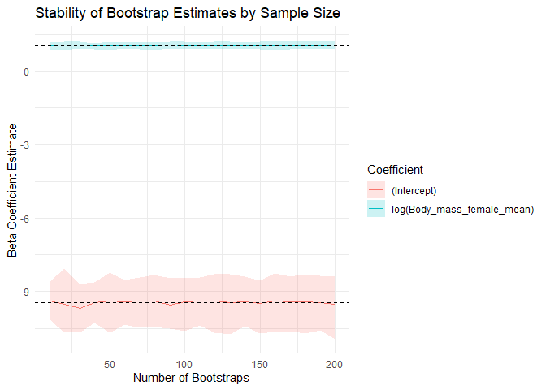

```r
bootstrap_trace(d, "log(HomeRange_km2) ~ log(Body_mass_female_mean)")
```